# Decision Trees Classification using Text Data

### Introduction

In this section, I will introduce the process of applying the Decision Trees (DT) to text data classification, the dataset I use for DT classfication, as well as the the classfication results.

The text data I will be using for DT classification is the Twitter reponse dataset (tweetEN_clean.csv) and its count vectorizer dataset (tweetEN_CountVectorizer.csv) that was cleaned and used in the previous sections, which can be found [here](https://github.com/anly501/anly-501-project-yeyaxin1103/tree/main/data/01-modified-data). The Twitter reponse dataset contains 11 attributes. The labels of this dataset are multiclasses that contain three classes: "negative", "positive" and "neutral".

A snapshot of the dataset will be shown in the class distribution section below.

### What is Decision Tree?

A Decision Tree is a descision support tool that uses a tree-like model of decision and their possible possible consequences, including chance event outcomes, resource costs, and utility. [Source: Wikipedia](https://en.wikipedia.org/wiki/Decision_tree)

Decision Trees (DTs) are non-parametric supervised learning method used for classification and regression. The deeper the tree, the more complex the decision rules and the fitter the model.

Advantages of Decision Trees (DT):

- Simple to interpret and implement
- Trees can be visualized easily
- Requires little data preparation (data normalization not required)
- Able to handle multi-output problems
- Able to handle both numerical and categorical data
- Possible to validate a model using statistical tests

Disadvantages of Decision Trees (DT):

- Tend to overfit
- Can be unstable since small variations in the data might result in completely different results
- Not very good at extrapolation
- Might create biased trees if some classes dominate

[Source: scikit-learn.org](https://scikit-learn.org/stable/modules/tree.html)

Here is an example of a decision tree [source](https://www.researchgate.net/figure/An-example-of-a-simple-decision-tree_fig2_311614501):

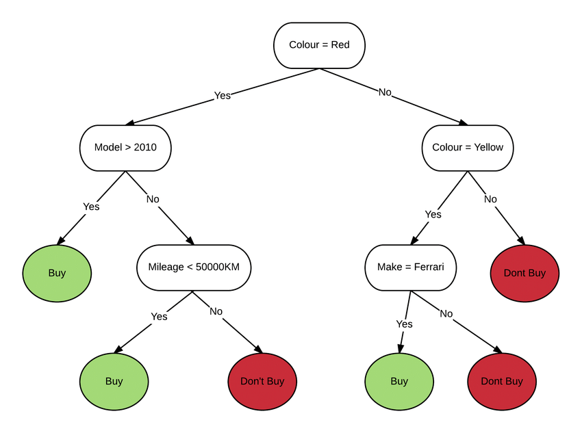

```python
from IPython.display import Image
Image(filename='DT_example.png')
```

Here are the elements of a decision tree [source](https://venngage.com/blog/what-is-a-decision-tree/):

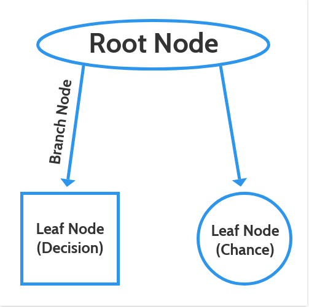

```python
Image(filename='node.png')
```

### Class Distribution

Compute the distribution of class labels in the Tweet dataset, since it might affect the classification algorithm results.

```python
import pandas as pd
import numpy as np
import random
from collections import Counter
from sklearn.metrics import accuracy_score
from sklearn.metrics import precision_recall_fscore_support
import seaborn as sns
import matplotlib.pyplot as plt
from IPython.display import Image
from sklearn.metrics import accuracy_score
from sklearn.metrics import precision_score
from sklearn.metrics import recall_score
```

Below is a snapshot of the dataset:

```python
#import dataset
df = pd.read_csv("../../data/01-modified-data/tweetEN_clean.csv")
df.head()
```

|  | author_id | id | created_at | text | clean_text | tweet_tokenized | tweet_nonstop | tweet_stemmed | tweet_lemmatized | sentiment | label |
| --- | --- | --- | --- | --- | --- | --- | --- | --- | --- | --- | --- |
| 0 | 1116548763168858112 | 1575191634026717184 | 2022-09-28T18:32:05.000Z | RT @VSkirbekk: Gradual convergence in fertilit... | gradual convergence fertility between china we... | ['gradual', 'convergence', 'fertility', 'betwe... | ['gradual', 'convergence', 'fertility', 'china... | ['gradual', 'converg', 'fertil', 'china', 'wes... | ['gradual', 'convergence', 'fertility', 'china... | 0.0000 | neutral |
| 1 | 1364997075851599873 | 1575190110920114178 | 2022-09-28T18:26:02.000Z | RT @nytimes: South Korea has had the world's l... | south korea world lowest total fertility rate ... | ['south', 'korea', 'world', 'lowest', 'total',... | ['south', 'korea', 'world', 'lowest', 'total',... | ['south', 'korea', 'world', 'lowest', 'total',... | ['south', 'korea', 'world', 'lowest', 'total',... | 0.2415 | positive |
| 2 | 1231317688288468994 | 1575189759550693377 | 2022-09-28T18:24:38.000Z | RT @nytimes: South Korea has had the world's l... | south korea world lowest total fertility rate ... | ['south', 'korea', 'world', 'lowest', 'total',... | ['south', 'korea', 'world', 'lowest', 'total',... | ['south', 'korea', 'world', 'lowest', 'total',... | ['south', 'korea', 'world', 'lowest', 'total',... | 0.2415 | positive |
| 3 | 780710885186674688 | 1575188100078133248 | 2022-09-28T18:18:03.000Z | RT @nytimes: South Korea has had the world's l... | south korea world lowest total fertility rate ... | ['south', 'korea', 'world', 'lowest', 'total',... | ['south', 'korea', 'world', 'lowest', 'total',... | ['south', 'korea', 'world', 'lowest', 'total',... | ['south', 'korea', 'world', 'lowest', 'total',... | 0.2415 | positive |
| 4 | 178464094 | 1575186284808531969 | 2022-09-28T18:10:50.000Z | RT @koryodynasty: Always trust men to come up ... | always trust come with policies women this cas... | ['always', 'trust', 'come', 'with', 'policies'... | ['always', 'trust', 'come', 'policies', 'women... | ['alway', 'trust', 'come', 'polici', 'women', ... | ['always', 'trust', 'come', 'policy', 'woman',... | 0.7184 | positive |

```python
print('--------- Label Counts ---------\n', df['label'].value_counts())
print('\n-------- Label Percentage -------\n', (df['label'].value_counts())/df.shape[0])
```

```
--------- Label Counts ---------
 positive    344
negative    279
neutral     152
Name: label, dtype: int64

-------- Label Percentage -------
 positive    0.443871
negative    0.360000
neutral     0.196129
Name: label, dtype: float64
```

**Interpretation:** Based on the label distribution results above, we can tell that the distribution of the three classes (negative, positive, neutral) is very imbalanced, which might result in a very poor predictive performance of the claasification model, especially for the minority class. [Source](https://machinelearningmastery.com/what-is-imbalanced-classification/)

### Baseline Model for Comparison

In this part, I will run a random classifier on your data and output accuracy, precision, and recall values in order to have a better preview of the possible classfication results using this dataset. The code of the random classifier is provided by Professor James Hickman.

```python
def generate_label_data(class_labels, weights, N=10000):
    # e.g. class_labels=[0,1] weights=[0.2, 0.8] (should sum to one)

    y = random.choices(class_labels, weights = weights, k = N)
    print("-----GENERATING DATA-----")
    print("unique entries:",Counter(y).keys())
    print("count of labels:",Counter(y).values()) # counts the elements' frequency
    print("probability of labels:",np.fromiter(Counter(y).values(), dtype=float)/len(y)) # counts the elements' frequency
    return y


 ## RANDOM CLASSIFIER
def random_classifier(y_data):
    ypred=[]
    max_label=np.max(y_data); #print(max_label)
    for i in range(0,len(y_data)):
        ypred.append(int(np.floor((max_label+1)*np.random.uniform(0,1))))
    print("-----RANDOM CLASSIFIER-----")
    print("count of prediction:",Counter(ypred).values()) # counts the elements' frequency
    print("probability of prediction:",np.fromiter(Counter(ypred).values(), dtype=float)/len(y_data)) # counts the elements' frequency
    print("accuracy",accuracy_score(y_data, ypred))
    print("percision, recall, fscore,",precision_recall_fscore_support(y_data, ypred))
```

Using random classifier on the Tweet text data based on the weights calculated above to get accuracy, precision, and recall values. In this part, I used 0 to represent the label "positive", 1 as "negative", and 2 as "neutral".

```python
# using random classifier on the Tweet text data based on the weights calculated above
print("--- Using Random Classifier on the Twitter Text Data ---\n")
y=generate_label_data([0,1,2],[0.443871,0.36,0.196129],df.shape[0])
random_classifier(y)
```

```
--- Using Random Classifier on the Twitter Text Data ---

-----GENERATING DATA-----
unique entries: dict_keys([1, 0, 2])
count of labels: dict_values([273, 357, 145])
probability of labels: [0.35225806 0.46064516 0.18709677]
-----RANDOM CLASSIFIER-----
count of prediction: dict_values([265, 261, 249])
probability of prediction: [0.34193548 0.33677419 0.32129032]
accuracy 0.3445161290322581
percision, recall, fscore, (array([0.46987952, 0.35849057, 0.21072797]), array([0.32773109, 0.34798535, 0.37931034]), array([0.38613861, 0.35315985, 0.27093596]), array([357, 273, 145]))
```

**Interpretation:** Based on the results generated by the random classifier above, we can see that the expected accuracy, precision, recall and fscore of using this data are low. Probabily due to to the heavily inequal distribution of the labels/classes.

### Data Pre-Processing

```python
df = df[['tweet_lemmatized', 'label']]
df.head()
```

|  | tweet_lemmatized | label |
| --- | --- | --- |
| 0 | ['gradual', 'convergence', 'fertility', 'china... | neutral |
| 1 | ['south', 'korea', 'world', 'lowest', 'total',... | positive |
| 2 | ['south', 'korea', 'world', 'lowest', 'total',... | positive |
| 3 | ['south', 'korea', 'world', 'lowest', 'total',... | positive |
| 4 | ['always', 'trust', 'come', 'policy', 'woman',... | positive |

1. Shuffling Data: reorganizing the index of the dataset

```python
np.random.shuffle(df.values)
print(df.shape)
df.head()
```

```
(775, 2)
```

|  | tweet_lemmatized | label |
| --- | --- | --- |
| 0 | ['according', 'survey', 'fertility', 'expert',... | positive |
| 1 | ['weasel', 'attic', 'translated', 'acclaimed',... | neutral |
| 2 | ['please', 'awnser', 'question', 'fertility', ... | negative |
| 3 | ['china', 'launched', 'nationwide', 'survey', ... | positive |
| 4 | ['south', 'korea', 'shattered', 'record', 'wor... | negative |

1. Import the count vectorizer (word count) data of the Tweet data generated in the previous steps, and then concatenate the label column to the count vectorizer data frame as the last attribute

```python
vector_df = pd.read_csv('../../data/01-modified-data/tweetEN_CountVectorizer.csv')
vector_df['label'] = df[['label']]
print(vector_df.shape)
vector_df.head()
```

```
(265, 1671)
```

|  | ability | able | abortion | abortions | about | above | abroad | abrupt | acclaimed | according | ... | yorubas | young | younger | youngness | your | youth | zmianie | zoomers | zuki | label |
| --- | --- | --- | --- | --- | --- | --- | --- | --- | --- | --- | --- | --- | --- | --- | --- | --- | --- | --- | --- | --- | --- |
| 0 | 0 | 0 | 0 | 0 | 0 | 0 | 0 | 0 | 0 | 0 | ... | 0 | 0 | 0 | 0 | 0 | 0 | 0 | 0 | 0 | negative |
| 1 | 0 | 0 | 0 | 0 | 0 | 0 | 0 | 0 | 0 | 0 | ... | 0 | 0 | 0 | 0 | 1 | 0 | 0 | 0 | 0 | negative |
| 2 | 0 | 0 | 0 | 0 | 0 | 0 | 0 | 0 | 0 | 0 | ... | 0 | 0 | 0 | 0 | 0 | 0 | 0 | 0 | 0 | negative |
| 3 | 0 | 0 | 0 | 0 | 0 | 0 | 0 | 0 | 0 | 0 | ... | 0 | 0 | 0 | 0 | 0 | 0 | 0 | 0 | 0 | neutral |
| 4 | 0 | 0 | 0 | 0 | 0 | 0 | 0 | 0 | 0 | 0 | ... | 0 | 0 | 0 | 0 | 0 | 0 | 0 | 0 | 0 | positive |

5 rows × 1671 columns

1. Input matrix X is the count vectorizer data without the label column. Output matrix y is the label column

```python
X =  vector_df.loc[:, vector_df.columns != 'label']
y = vector_df.loc[:, 'label']
print('Shape of X:', X.shape)
print('Shape of y:', y.shape)
```

```
Shape of X: (265, 1670)
Shape of y: (265,)
```

1. Splitting Dataset into Training and Testing Data using Count Vectorizer Data of the Text

```python
from sklearn.model_selection import train_test_split

test_ratio = 0.15
x_train, x_test, y_train, y_test = train_test_split(X, y, test_size = test_ratio, random_state = 0)
y_train = y_train.squeeze()
y_test = y_test.squeeze()

print('X_train.shape		:', x_train.shape)
print('y_train.shape		:', y_train.shape)
print('X_test.shape		:', x_test.shape)
print('y_test.shape		:', y_test.shape)
```

```
X_train.shape		: (225, 1670)
y_train.shape		: (225,)
X_test.shape		: (40, 1670)
y_test.shape		: (40,)
```

### Model Training: Decision Tree

Import packages and train the model using training data

```python
from sklearn import tree
model = tree.DecisionTreeClassifier()
model = model.fit(x_train, y_train)
```

#### Check Results

Evaluate the performance of the decision tree model by using the test data

```python
yp_train = model.predict(x_train)
yp_test = model.predict(x_test)
```

```python
from sklearn.metrics import confusion_matrix, ConfusionMatrixDisplay

def confusion_plot(y_data, y_pred):
    cm = confusion_matrix(y_data, y_pred)
    print('ACCURACY:', accuracy_score(y_data, y_pred))
    print('RECALL SCORE:', recall_score(y_data, y_pred, average=None))
    print('PRECISION SCORE:', precision_score(y_data, y_pred, average=None))
    print(cm)
    disp = ConfusionMatrixDisplay(confusion_matrix=cm)
    disp.plot()
```

```
------ TRAINING ------
ACCURACY: 1.0
RECALL SCORE: [1. 1. 1.]
PRECISION SCORE: [1. 1. 1.]
[[ 83   0   0]
 [  0  41   0]
 [  0   0 101]]
------- TESTING ------
ACCURACY: 0.3
RECALL SCORE: [0.35714286 0.08333333 0.42857143]
PRECISION SCORE: [0.27777778 0.2        0.35294118]
[[5 3 6]
 [6 1 5]
 [7 1 6]]
```

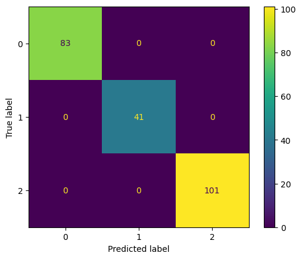

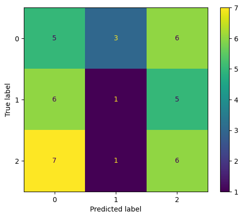

```python
print("------ TRAINING ------")
confusion_plot(y_train,yp_train)
print("------- TESTING ------")
confusion_plot(y_test,yp_test)
```

### Hyper-Parameter Adjustment

The "max_depth" hyper-parameter controls the number of layers in the tree. In this part, I will try to find the set of hyper-parameters with the lowest training AND test error by iterating over "max_depth".

```python
test_results=[]
train_results=[]

for num_layer in range(1,30):
    model = tree.DecisionTreeClassifier(max_depth=num_layer)
    model = model.fit(x_train, y_train)

    yp_train=model.predict(x_train)
    yp_test=model.predict(x_test)

    # print(y_pred.shape)
    test_results.append([num_layer,accuracy_score(y_test, yp_test),recall_score(y_test, yp_test, average = None)])
    train_results.append([num_layer,accuracy_score(y_train, yp_train),recall_score(y_train, yp_train, average = None)])
```

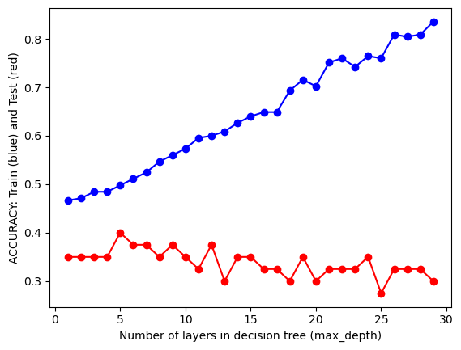

```python
test_layer = [item[0] for item in test_results]
test_accuracy = [item[1] for item in test_results]
train_layer = [item[0] for item in train_results]
train_accuracy = [item[1] for item in train_results]

plt.plot(test_layer, test_accuracy, color = 'red', marker = 'o')
plt.plot(train_layer, train_accuracy, color = 'blue', marker = 'o')

plt.xlabel("Number of layers in decision tree (max_depth)")
plt.ylabel("ACCURACY: Train (blue) and Test (red)")
```

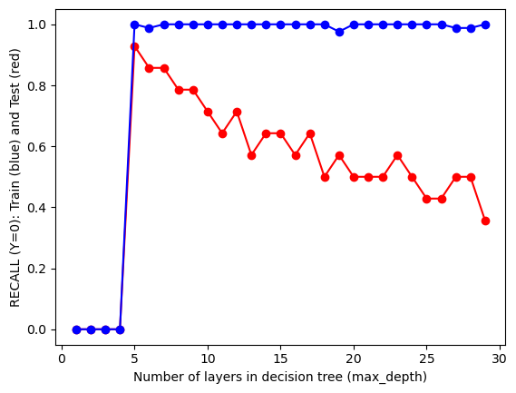

```python
test_layer = [item[0] for item in test_results]
test_recall = [item[2][0] for item in test_results]
train_layer = [item[0] for item in train_results]
train_recall = [item[2][0] for item in train_results]

plt.plot(test_layer, test_recall, color = 'red', marker = 'o')
plt.plot(train_layer, train_recall, color = 'blue', marker = 'o')

plt.xlabel("Number of layers in decision tree (max_depth)")
plt.ylabel("RECALL (Y=0): Train (blue) and Test (red)")
```

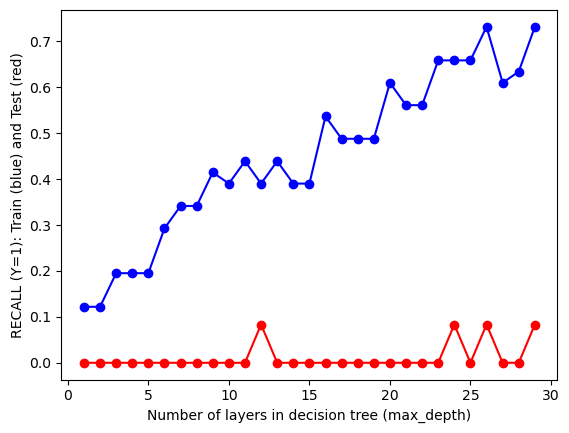

```python
test_layer = [item[0] for item in test_results]
test_recall = [item[2][1] for item in test_results]
train_layer = [item[0] for item in train_results]
train_recall = [item[2][1] for item in train_results]

plt.plot(test_layer, test_recall, color = 'red', marker = 'o')
plt.plot(train_layer, train_recall, color = 'blue', marker = 'o')

plt.xlabel("Number of layers in decision tree (max_depth)")
plt.ylabel("RECALL (Y=1): Train (blue) and Test (red)")
```

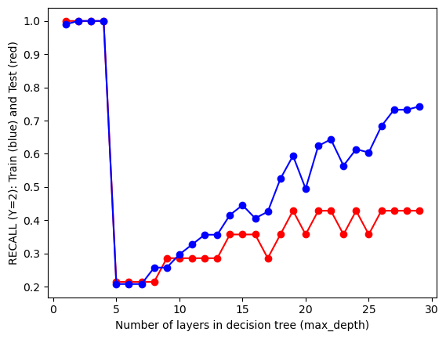

```python
test_layer = [item[0] for item in test_results]
test_recall = [item[2][2] for item in test_results]
train_layer = [item[0] for item in train_results]
train_recall = [item[2][2] for item in train_results]

plt.plot(test_layer, test_recall, color = 'red', marker = 'o')
plt.plot(train_layer, train_recall, color = 'blue', marker = 'o')

plt.xlabel("Number of layers in decision tree (max_depth)")
plt.ylabel("RECALL (Y=2): Train (blue) and Test (red)")
```

Based on the plots generated above, a max_depth of 5 seems to be the most optimal option for this decision tree.

### Train Optimal Model & Visualize the Tree

Re-train the decision tree using the optimal hyper-parameter obtained from the plot above, which is the max_depth of 5.

```python
def plot_tree(model,X,Y):
    fig = plt.figure(figsize=(25,20))
    _ = tree.plot_tree(model,
                    filled=True)
    plt.show()
```

```
------ TRAINING ------
ACCURACY: 0.49777777777777776
RECALL SCORE: [1.         0.19512195 0.20792079]
PRECISION SCORE: [0.42346939 1.         1.        ]
[[83  0  0]
 [33  8  0]
 [80  0 21]]
------ TESTING ------
ACCURACY: 0.4
RECALL SCORE: [0.92857143 0.         0.21428571]
PRECISION SCORE: [0.37142857 0.         0.6       ]
[[13  0  1]
 [11  0  1]
 [11  0  3]]
```

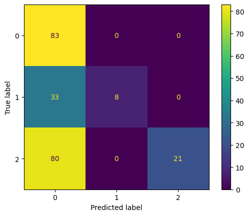

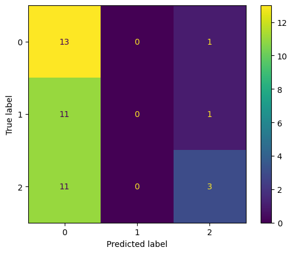

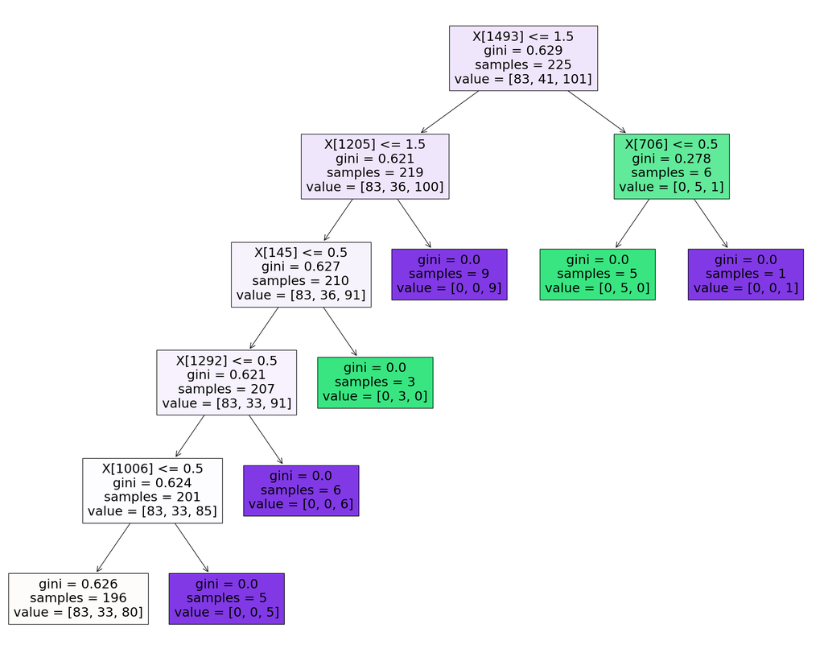

```python
model = tree.DecisionTreeClassifier(max_depth = 5)
model = model.fit(x_train, y_train)

yp_train=model.predict(x_train)
yp_test=model.predict(x_test)

print("------ TRAINING ------")
confusion_plot(y_train,yp_train)
print("------ TESTING ------")
confusion_plot(y_test,yp_test)

plot_tree(model,X,y)
```

**Interpretation:** According to the results and the visualization of the new decision tree using the max_depth of 5, we can see that although the accuracy has improved by 10% (from 30% to 40%), the overall predictive performance of the decision tree model is still not ideal for this text dataset.

### Conclusion

Based on the classification reports above, we can see that the predictive performance of the Decision Trees (DT) classifier on the testing data is not ideal and even a bit poor with a 40% accuracy. The possible reasons that caused this poor prediction are:

- the very limited data size
- the heavily imbalanced classes
- the feasibility of the model for the text data